# AG3C_PCA

## Results

### All Samples, All Conditions, All Time Points

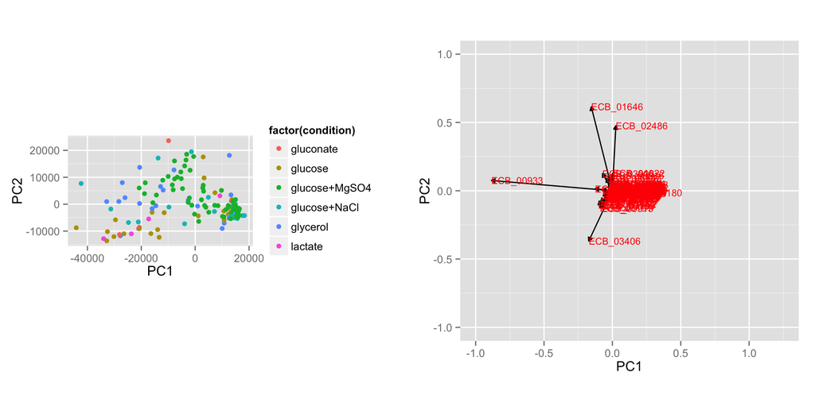

This plot doesn’t show much separation between the conditions, probably because there is such a diverse mixture of time points and growth conditions. However, the rotations show that ECB_00933, ECB_01646, ECB_02486, and ECB_03406 contribute the most to PC1 and PC2.

### All Samples, All Conditions, <24 Hours

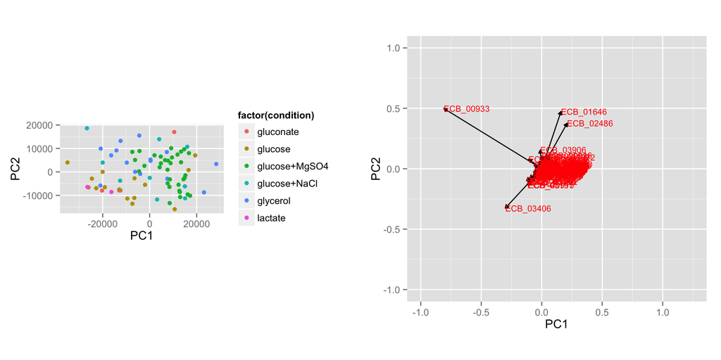

### All Samples, All Condtions, for each time point.

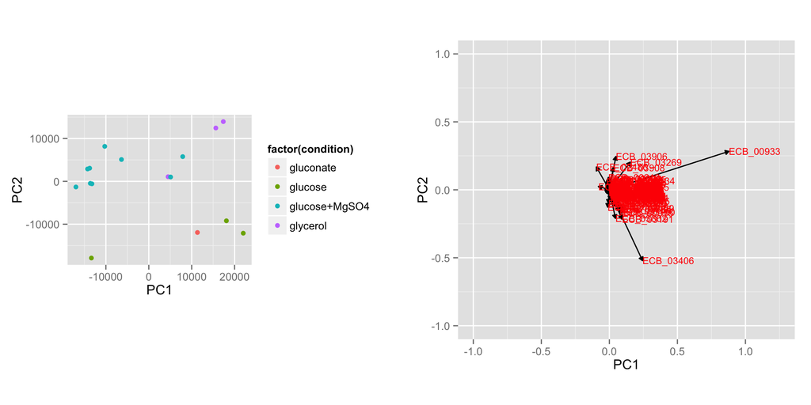

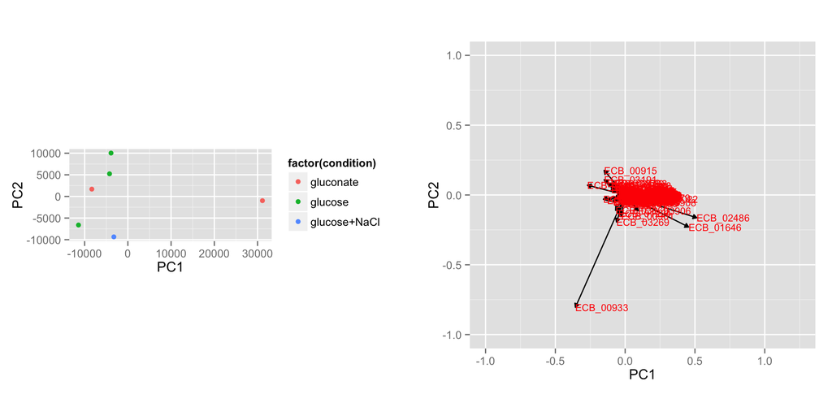

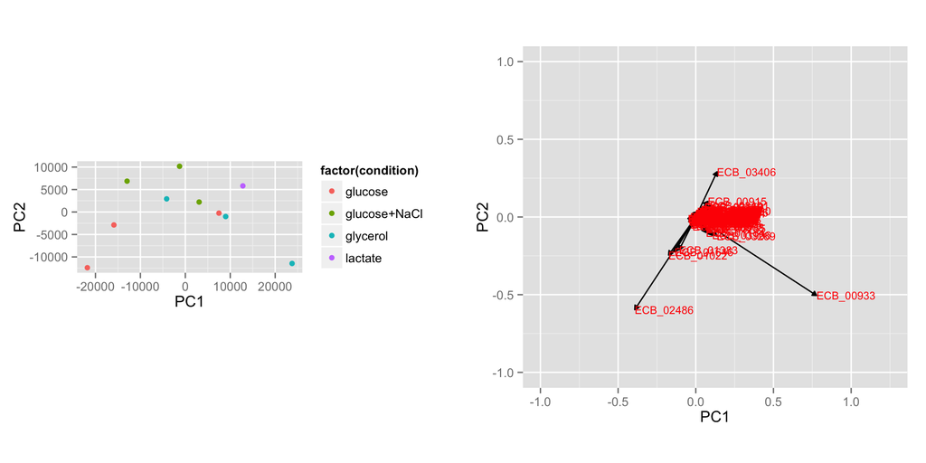

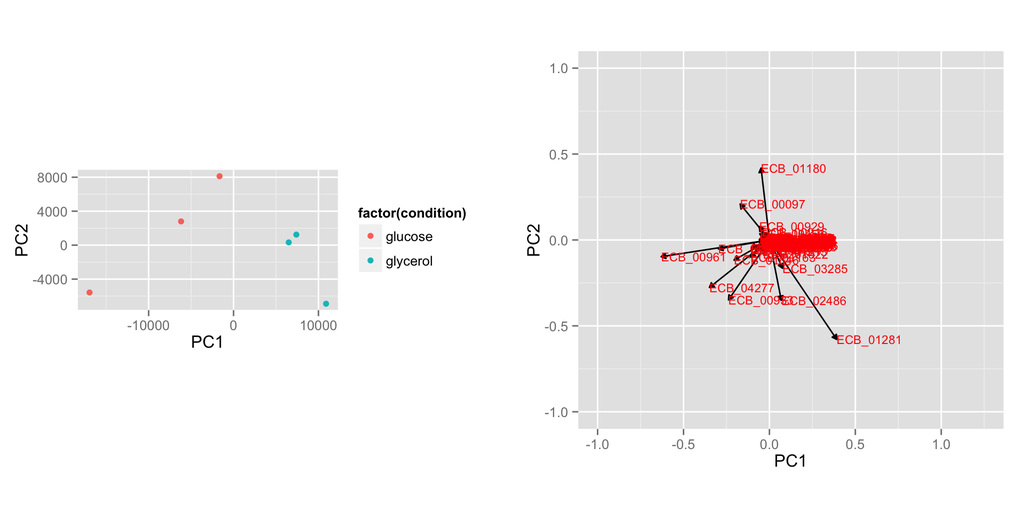

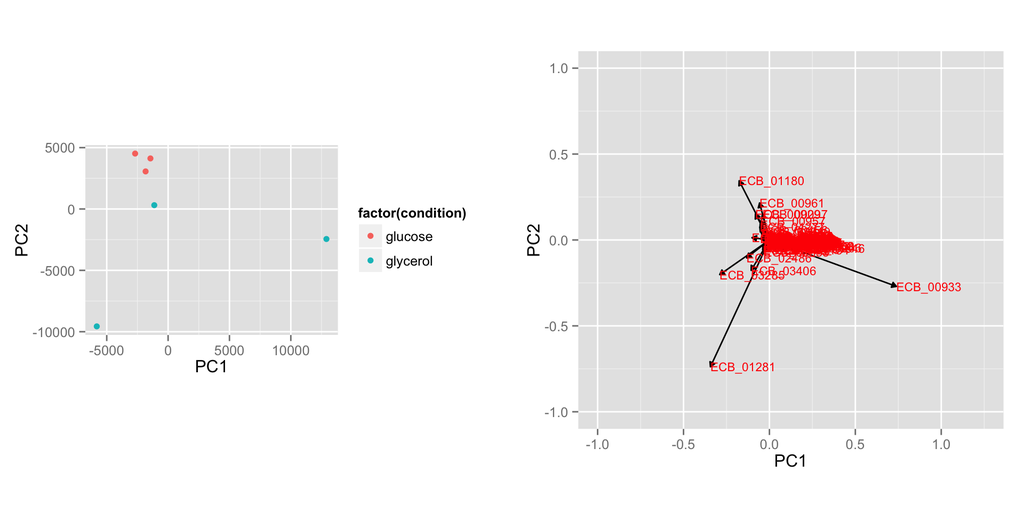

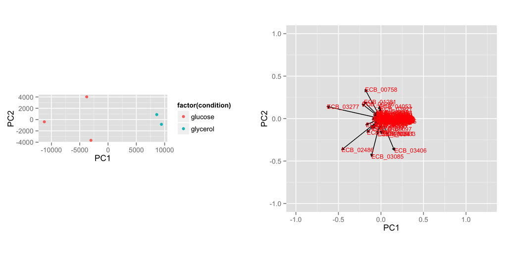

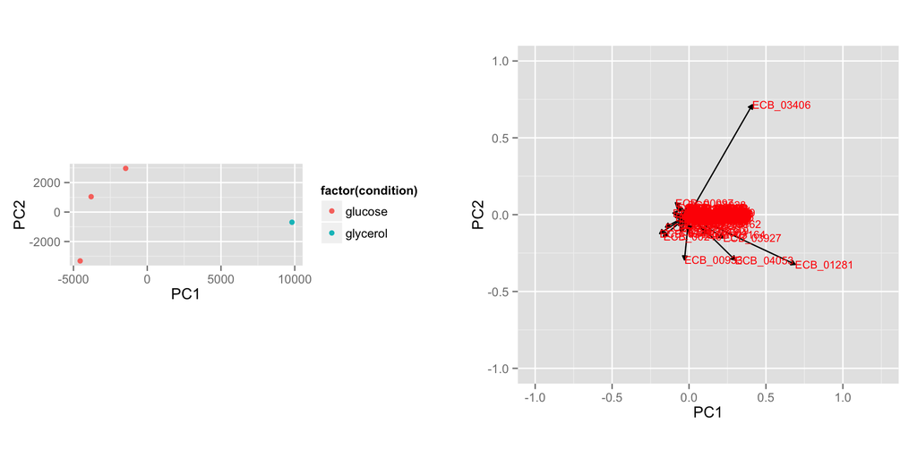

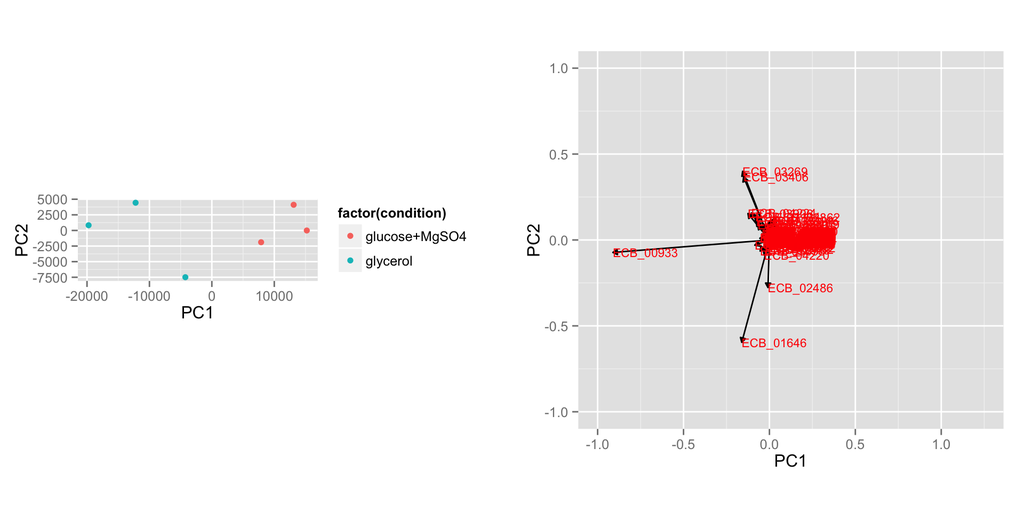

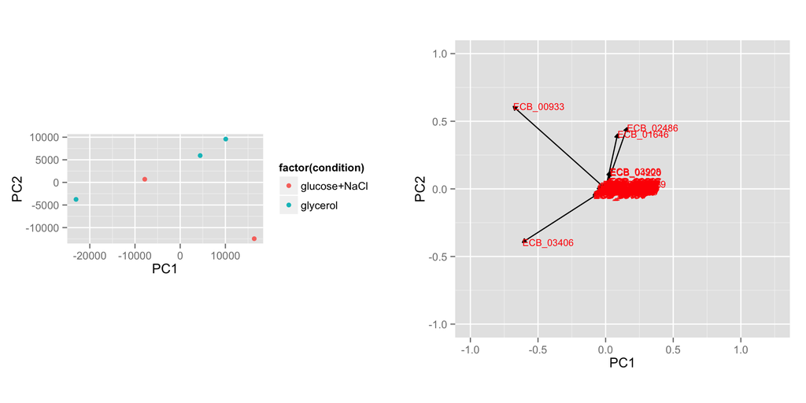

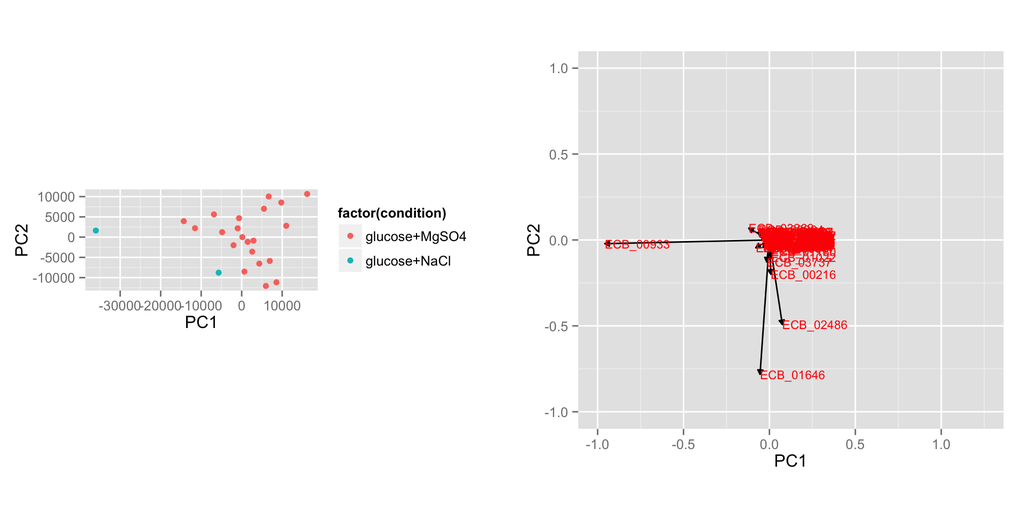

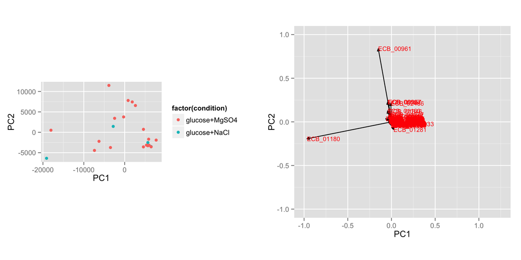

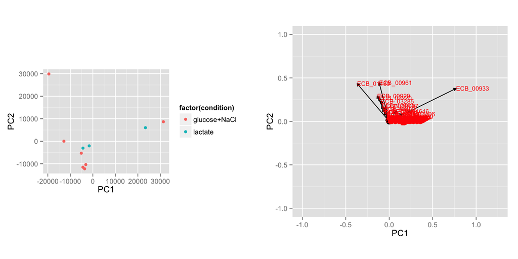

## Methods

### Principal Component Analysis

We did data manipulations, PCA calculations, and data visualizations in R 3.1.2 [1]. We used two R packages, tidyr and dplyr, to format and filter data for given growth conditions and time points [2,3]. After filtering, we used prcomp (R built-in function) with default arguments to do PCA. prcomp uses singular value decomposition method, which is a preferred method for genome-wide expression data analysis [4]. For all PCA plots we used R package ggplot2 [5]. Our code for this section is available [here](https://github.com/dariyasydykova/AG3C_pca_mrna).